# Seventh Week: Generalized Linear Models

Murder or suicide

مهسا خوش نما 93101481

2018-04-27 10:39:22

[figure not shown]

> با توجه به سوالات مرگ و میر در آمریکا به سوالات زیر پاسخ دهید.

```r
library(readxl)
library(dplyr)
library(ggplot2)
library(Hmisc)
library(corrplot)
library(car)
library(reshape2)
library(tidytext)
library(rlist)
library(gridExtra)
library(ggthemes)
library(knitr)
library(kableExtra)
source("unbalanced_functions.R")
data = read.csv("data/murder_suicide.csv")
```

۱. از میان متغیرهای داده مرگ و میر یک زیرمجموعه ایی بدون حشو در نظر بگیرید. ماتریس همبستگی متغیرهای مختلف را به دست آورده و سپس رسم نمایید. علاوه بر این نمودار پراکنش متغیرهای انتخاب شده را همزمان نسبت به هم رسم نمایید.

### پاسخ:

ابتدامتغیرهای مربوط به تحصیلات را که بر اساس سال 1989 و 2003 آمده اند را یکسان سازی می کنیم.سپس ویژگی هایی را که به صورت categorical هستند به ویژگی های عددی تبدیل می کنیم. همچنین داده هایی که متغیر سن در آن ها ذکر نشده است(که تعداد بسیار کمی دارند) را حذف کرده و سن همه ی داده ها را یکسان سازی کرده و به سال تبدیل می کنیم. نهایتا از بین ویژگی هایی که اطلاعات مشابهی را می رسانند آن ویژگی که بیشترین اطلاعات را منتقل میکند انتخاب می کنیم. سپس مقدار قدر مطلق correlation دو به دوی این متغیرها را رسم می کنیم و از بین متغیرهایی که با هم correlation زیادی دارند یکی را انتخاب می کنیم تا نهایتا به مجموعه ی نهایی ویژگی ها برسیم.

```r
#combining educations reported in 2003 and 1989
rbind(data %>% filter(EducationReportingFlag==1) %>% mutate(Education = Education2003Revision) %>%
  select(-EducationReportingFlag,-Education2003Revision,-Education1989Revision),
  data %>% filter(EducationReportingFlag==0) %>% mutate(Education =
            recode(Education1989Revision,"0:8= 1;9:11=2;12=3;13:15=4;16=6;17=7;else=9")) %>%
  select(-EducationReportingFlag,-Education2003Revision,-Education1989Revision)) -> stat

#numerising the categorical features
stat %>% select_if(is.factor) %>% data.matrix %>% as.numeric() %>%
  matrix(nrow = nrow(stat)) %>% data.frame -> stat2
colnames(stat2) = stat %>% select_if(is.factor) %>% colnames()
cbind(stat %>% select_if(is.numeric),
      stat2)->stat


#Adjusting the age
stat %>% group_by(AgeType) %>% summarise(n())
```

```
## # A tibble: 6 x 2
##   AgeType `n()`
##     <int> <int>
## 1       1 59699
## 2       2   234
## 3       4    16
## 4       5     7
## 5       6    10
## 6       9    13
```

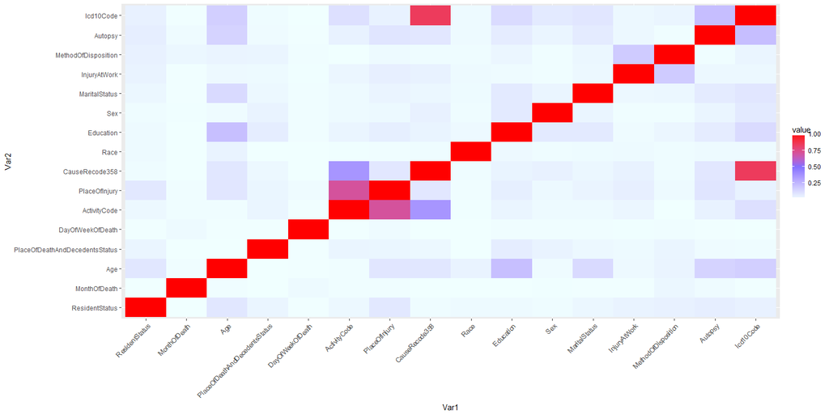

```r
stat %>% filter(AgeType!=9) -> stat


stat %>% select(-Id,-AgeType,-AgeRecode52,-AgeRecode27,-AgeRecode12,-AgeSubstitutionFlag,
                -InfantAgeRecode22,-InfantCauseRecode130,-CauseRecode113,-CauseRecode39,-RaceImputationFlag,
                -RaceRecode3,-RaceRecode5,-BridgedRaceFlag,-HispanicOrigin,-HispanicOriginRaceRecode,
                -MannerOfDeath,-CurrentDataYear,-NumberOfEntityAxisConditions,
                -NumberOfRecordAxisConditions) %>%
        mutate(label = recode(stat$MannerOfDeath,"2=0;3=1")) -> train  #0:suicide 1:homicide
corr = rcorr(as.matrix(train %>% select(-label)))
corr_matrix = corr[[1]]
melted_cormat <- melt(abs(corr_matrix))
ggplot(data = melted_cormat, aes(x=Var1, y=Var2, fill=value)) +
  geom_tile() +
  theme(axis.text.x = element_text(angle = 45, hjust = 1, vjust = 1))+
  scale_fill_gradientn(colours = c("azure","slateblue1","red"), values = c(0,0.5,1))
```

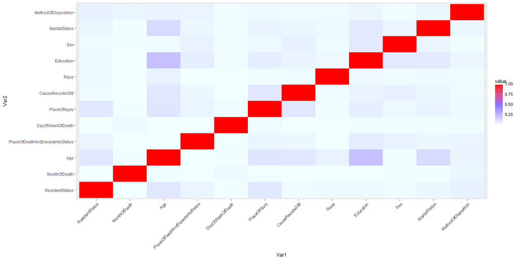

```r
train %>% select(-Icd10Code,-ActivityCode,-InjuryAtWork,-InjuryAtWork,-Autopsy) -> train

corr = rcorr(as.matrix(train %>% select(-label)))
corr_matrix = corr[[1]]
melted_cormat <- melt(abs(corr_matrix))
ggplot(data = melted_cormat, aes(x=Var1, y=Var2, fill=value)) +
  geom_tile() +
  theme(axis.text.x = element_text(angle = 45, hjust = 1, vjust = 1))+
  scale_fill_gradientn(colours = c("azure","slateblue1","red"), values = c(0,0.5,1))
```

نهایتا 12 ویژگی انتخاب می شوند که نمودار correlation و پراکنش دو به دوی آن ها به صورت زیر است:

```r
corr = rcorr(as.matrix(train %>% select(-label)))
corr_matrix = corr[[1]]
melted_cormat <- melt(abs(corr_matrix))
kable(corr_matrix) %>%  kable_styling() %>%
  scroll_box(width = "900px", height = "600px")
```

|  | ResidentStatus | MonthOfDeath | Age | PlaceOfDeathAndDecedentsStatus | DayOfWeekOfDeath | PlaceOfInjury | CauseRecode358 | Race | Education | Sex | MaritalStatus | MethodOfDisposition |
| --- | --- | --- | --- | --- | --- | --- | --- | --- | --- | --- | --- | --- |
| ResidentStatus | 1.0000000 | 0.0007903 | -0.0814560 | 0.0325170 | 0.0026091 | 0.0782756 | 0.0117451 | 0.0156814 | 0.0173761 | 0.0106579 | 0.0263232 | 0.0459942 |
| MonthOfDeath | 0.0007903 | 1.0000000 | -0.0081391 | 0.0017113 | -0.0165473 | -0.0052250 | 0.0013348 | 0.0004769 | 0.0007245 | 0.0038091 | 0.0028086 | -0.0260113 |
| Age | -0.0814560 | -0.0081391 | 1.0000000 | -0.0013513 | -0.0024200 | -0.0840604 | -0.0820114 | -0.0409409 | 0.2159528 | -0.0129930 | -0.1263530 | 0.0366792 |
| PlaceOfDeathAndDecedentsStatus | 0.0325170 | 0.0017113 | -0.0013513 | 1.0000000 | 0.0030212 | 0.0319497 | 0.0221382 | -0.0007313 | 0.0618099 | 0.0410095 | -0.0248653 | 0.0332763 |
| DayOfWeekOfDeath | 0.0026091 | -0.0165473 | -0.0024200 | 0.0030212 | 1.0000000 | 0.0133869 | 0.0003871 | -0.0004008 | -0.0081099 | 0.0055386 | 0.0069902 | -0.0060438 |
| PlaceOfInjury | 0.0782756 | -0.0052250 | -0.0840604 | 0.0319497 | 0.0133869 | 1.0000000 | -0.0808122 | 0.0062647 | -0.0550995 | 0.0204928 | 0.0360709 | -0.0173671 |
| CauseRecode358 | 0.0117451 | 0.0013348 | -0.0820114 | 0.0221382 | 0.0003871 | -0.0808122 | 1.0000000 | 0.0099193 | -0.0385868 | 0.0457374 | 0.0273547 | -0.0116252 |
| Race | 0.0156814 | 0.0004769 | -0.0409409 | -0.0007313 | -0.0004008 | 0.0062647 | 0.0099193 | 1.0000000 | 0.0193880 | -0.0093560 | 0.0150836 | 0.0093952 |
| Education | 0.0173761 | 0.0007245 | 0.2159528 | 0.0618099 | -0.0081099 | -0.0550995 | -0.0385868 | 0.0193880 | 1.0000000 | -0.0711610 | -0.0704399 | 0.0313379 |
| Sex | 0.0106579 | 0.0038091 | -0.0129930 | 0.0410095 | 0.0055386 | 0.0204928 | 0.0457374 | -0.0093560 | -0.0711610 | 1.0000000 | 0.0334552 | -0.0085156 |
| MaritalStatus | 0.0263232 | 0.0028086 | -0.1263530 | -0.0248653 | 0.0069902 | 0.0360709 | 0.0273547 | 0.0150836 | -0.0704399 | 0.0334552 | 1.0000000 | -0.0261973 |
| MethodOfDisposition | 0.0459942 | -0.0260113 | 0.0366792 | 0.0332763 | -0.0060438 | -0.0173671 | -0.0116252 | 0.0093952 | 0.0313379 | -0.0085156 | -0.0261973 | 1.0000000 |

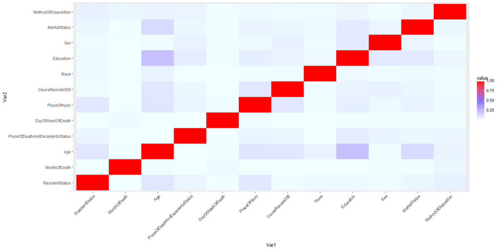

```r
ggplot(data = melted_cormat, aes(x=Var1, y=Var2, fill=value)) +
  geom_tile() +
  theme(axis.text.x = element_text(angle = 45, hjust = 1, vjust = 1))+
  scale_fill_gradientn(colours = c("azure","slateblue1","red"), values = c(0,0.5,1))
```

```r
plots = list()
vars = colnames(train)[-13]
for (i in 2:12){
  for(j in 1:(i-1)){
  p = ggplot(data = train,aes(x=train %>% select(vars[i]), y=train %>% select(vars[j])))+
    ylab(vars[j])+xlab(vars[i])+geom_point(aes(size = train %>% select(vars[i]))) +
    theme(legend.position = "none") +
    geom_smooth(method="lm", formula=y~x, colour = "blue")
  plots = list.append(plots,p)
  }
}
do.call(grid.arrange,c(plots,ncol = 2))
```

[figure not shown]

۲. اثر هر یک از متغیرهای جنسیت، نژاد،آموزش، سن و نحوه تدفین را بر مرگ یا خودکشی ارزیابی کنید.

### پاسخ:

```r
#Sex
train %>% select(label,Sex) %>%
  group_by(label,Sex) %>% summarise(count = n()) %>%
  tidyr::spread(Sex,count)  -> Sex
Sex %>% .[,-1] %>% as.matrix() -> SexMat
rownames(SexMat) = Sex$label
chisq.test(SexMat)
```

```
##
##  Pearson's Chi-squared test with Yates' continuity correction
##
## data:  SexMat
## X-squared = 24.188, df = 1, p-value = 8.737e-07
```

```r
#Race
train %>% select(label,Race) %>%
  group_by(label,Race) %>% summarise(count = n()) %>%
  tidyr::spread(Race,count)  -> Race
Race %>% .[,-1] %>% as.matrix() -> RaceMat
rownames(RaceMat) = Race$label
chisq.test(RaceMat)
```

```
##
##  Pearson's Chi-squared test
##
## data:  RaceMat
## X-squared = 15340, df = 13, p-value < 2.2e-16
```

```r
#Education
train %>% select(label,Education) %>%
  group_by(label,Education) %>% summarise(count = n()) %>%
  tidyr::spread(Education,count)  -> Edu
Edu %>% .[,-1] %>% as.matrix() -> EduMat
rownames(EduMat) = Edu$label
chisq.test(EduMat)
```

```
##
##  Pearson's Chi-squared test
##
## data:  EduMat
## X-squared = 3823.5, df = 8, p-value < 2.2e-16
```

```r
#Age
stat %>% select(MannerOfDeath,AgeRecode12) %>%
  group_by(MannerOfDeath,AgeRecode12) %>% summarise(count = n()) %>%
  tidyr::spread(AgeRecode12,count)  -> age
age %>% .[,-1] %>% as.matrix() -> ageMat
ageMat[which(is.na(ageMat),arr.ind = T)]= 0
rownames(ageMat) = age$MannerOfDeath
chisq.test(ageMat)
```

```
##
##  Pearson's Chi-squared test
##
## data:  ageMat
## X-squared = 6367.8, df = 11, p-value < 2.2e-16
```

```r
#Method of Disposition
train %>% select(label,MethodOfDisposition) %>%
  group_by(label,MethodOfDisposition) %>% summarise(count = n()) %>%
  tidyr::spread(MethodOfDisposition,count)  -> dispo
dispo %>% .[,-1] %>% as.matrix() -> dispoMat
rownames(dispoMat) = dispo$label
chisq.test(EduMat)
```

```
##
##  Pearson's Chi-squared test
##
## data:  EduMat
## X-squared = 3823.5, df = 8, p-value < 2.2e-16
```

۳. با استفاده از مدل رگرسیون لاجستیک یک مدل به داده ها برازش دهید و سپس آن را نقص یابی کنید.

### پاسخ:

برای نقص یابی مدل، از chi-squared test برای اختلاف بین null deviance و residual deviance استفاده می کنیم.

```r
logmod1 = glm(label~ResidentStatus+MonthOfDeath+Age+PlaceOfDeathAndDecedentsStatus+DayOfWeekOfDeath+
               PlaceOfInjury+CauseRecode358+Race+Education+Sex+MaritalStatus+MethodOfDisposition,
             data = train,family = binomial(link = 'logit'))
summary(logmod1)
```

```
##
## Call:
## glm(formula = label ~ ResidentStatus + MonthOfDeath + Age + PlaceOfDeathAndDecedentsStatus +
##     DayOfWeekOfDeath + PlaceOfInjury + CauseRecode358 + Race +
##     Education + Sex + MaritalStatus + MethodOfDisposition, family = binomial(link = "logit"),
##     data = train)
##
## Deviance Residuals:
##     Min       1Q   Median       3Q      Max
## -5.7760  -0.5801  -0.4056   0.5063   8.4904
##
## Coefficients:
##                                  Estimate Std. Error z value Pr(>|z|)
## (Intercept)                    -1.073e+02  1.225e+00 -87.569  < 2e-16 ***
## ResidentStatus                  3.997e-02  1.984e-02   2.014   0.0440 *
## MonthOfDeath                    2.586e-03  3.290e-03   0.786   0.4319
## Age                            -2.291e-02  6.640e-04 -34.496  < 2e-16 ***
## PlaceOfDeathAndDecedentsStatus -9.730e-02  5.385e-03 -18.070  < 2e-16 ***
## DayOfWeekOfDeath                5.736e-03  5.522e-03   1.039   0.2989
## PlaceOfInjury                   1.177e-01  1.708e-03  68.878  < 2e-16 ***
## CauseRecode358                  2.503e-01  2.837e-03  88.227  < 2e-16 ***
## Race                            2.801e-03  1.601e-03   1.749   0.0802 .
## Education                      -1.839e-01  7.646e-03 -24.057  < 2e-16 ***
## Sex                            -1.912e-01  2.753e-02  -6.946 3.75e-12 ***
## MaritalStatus                   1.815e-01  1.227e-02  14.795  < 2e-16 ***
## MethodOfDisposition            -4.451e-02  6.415e-03  -6.938 3.97e-12 ***
## ---
## Signif. codes:  0 '***' 0.001 '**' 0.01 '*' 0.05 '.' 0.1 ' ' 1
##
## (Dispersion parameter for binomial family taken to be 1)
##
##     Null deviance: 71196  on 59965  degrees of freedom
## Residual deviance: 44870  on 59953  degrees of freedom
## AIC: 44896
##
## Number of Fisher Scoring iterations: 7
```

```r
with(logmod1, pchisq(null.deviance - deviance, df.null - df.residual, lower.tail = FALSE))
```

```
## [1] 0
```

مقدار کوچک p-value به دست آمده از تست نشان می دهد که مدل ما نسبت به مدل بدون متغیر، خروجی را بهتر پیش بینی می کند.

نکنه ی قابل توجه دیگری که در summary مدل به چشم می خورد، این است که متغیر race، significant نبوده است در حالی که این متغیر قاعدتا باید در قتل های آمریکا مهم باشد. بنابراین این بار از داده های اصلی ویژگی دیگری که نشان دهنده ی نژادهاست را به جای متغیر Race انتخاب می کنیم.(RaceRecode3)

```r
stat %>% select(-Id,-AgeType,-AgeRecode52,-AgeRecode27,-AgeRecode12,-AgeSubstitutionFlag,
                -InfantAgeRecode22,-InfantCauseRecode130,-CauseRecode113,-CauseRecode39,-
                  RaceImputationFlag,-Race,-RaceRecode5,-BridgedRaceFlag,-HispanicOrigin,
                -HispanicOriginRaceRecode,-MannerOfDeath,-CurrentDataYear,
                -NumberOfEntityAxisConditions,-NumberOfRecordAxisConditions) %>%
  select(-Icd10Code,-ActivityCode,-InjuryAtWork,-InjuryAtWork,-Autopsy) %>%
  mutate(label = recode(stat$MannerOfDeath,"2=0;3=1")) -> train2  #0:suicide 1:homicide

logmod2 = glm(label~ResidentStatus+MonthOfDeath+Age+PlaceOfDeathAndDecedentsStatus+DayOfWeekOfDeath+
               PlaceOfInjury+CauseRecode358+RaceRecode3+Education+Sex+MaritalStatus+MethodOfDisposition,
             data = train2,family = binomial(link = 'logit'))
summary(logmod2)
```

```
##
## Call:
## glm(formula = label ~ ResidentStatus + MonthOfDeath + Age + PlaceOfDeathAndDecedentsStatus +
##     DayOfWeekOfDeath + PlaceOfInjury + CauseRecode358 + RaceRecode3 +
##     Education + Sex + MaritalStatus + MethodOfDisposition, family = binomial(link = "logit"),
##     data = train2)
##
## Deviance Residuals:
##     Min       1Q   Median       3Q      Max
## -5.4392  -0.5196  -0.3835   0.4027   8.4904
##
## Coefficients:
##                                  Estimate Std. Error z value Pr(>|z|)
## (Intercept)                    -8.360e+01  1.258e+00 -66.450  < 2e-16 ***
## ResidentStatus                  7.295e-02  2.088e-02   3.493 0.000477 ***
## MonthOfDeath                    1.775e-03  3.501e-03   0.507 0.612051
## Age                            -1.582e-02  6.987e-04 -22.635  < 2e-16 ***
## PlaceOfDeathAndDecedentsStatus -9.006e-02  5.770e-03 -15.609  < 2e-16 ***
## DayOfWeekOfDeath                4.249e-03  5.893e-03   0.721 0.470967
## PlaceOfInjury                   9.973e-02  1.749e-03  57.013  < 2e-16 ***
## CauseRecode358                  1.921e-01  2.920e-03  65.774  < 2e-16 ***
## RaceRecode3                     9.866e-01  1.480e-02  66.666  < 2e-16 ***
## Education                      -1.841e-01  7.972e-03 -23.092  < 2e-16 ***
## Sex                            -3.293e-01  2.857e-02 -11.527  < 2e-16 ***
## MaritalStatus                   1.203e-01  1.287e-02   9.347  < 2e-16 ***
## MethodOfDisposition            -3.696e-02  6.807e-03  -5.430 5.65e-08 ***
## ---
## Signif. codes:  0 '***' 0.001 '**' 0.01 '*' 0.05 '.' 0.1 ' ' 1
##
## (Dispersion parameter for binomial family taken to be 1)
##
##     Null deviance: 71196  on 59965  degrees of freedom
## Residual deviance: 43983  on 59953  degrees of freedom
## AIC: 44009
##
## Number of Fisher Scoring iterations: 7
```

```r
with(logmod2, pchisq(null.deviance - deviance, df.null - df.residual, lower.tail = FALSE))
```

```
## [1] 0
```

مشاهده می شود که AIC مدل نسبت به مدل قبلی کاهش پیدا کرده است که نشان دهنده ی عملکرد بهتر مدل جدید است. همچنین این بار متغیر مربوط به نژاد significant است. حال متغیرهایی که significant نبوده اند را از مدل حذف می کنیم تا مدل نهایی به دست بیاید.

```r
logmod = glm(label~ResidentStatus+Age+PlaceOfDeathAndDecedentsStatus+
                PlaceOfInjury+CauseRecode358+RaceRecode3+Education+Sex+MaritalStatus+MethodOfDisposition,
              data = train2,family = binomial(link = 'logit'))
summary(logmod)
```

```
##
## Call:
## glm(formula = label ~ ResidentStatus + Age + PlaceOfDeathAndDecedentsStatus +
##     PlaceOfInjury + CauseRecode358 + RaceRecode3 + Education +
##     Sex + MaritalStatus + MethodOfDisposition, family = binomial(link = "logit"),
##     data = train2)
##
## Deviance Residuals:
##     Min       1Q   Median       3Q      Max
## -5.4390  -0.5195  -0.3833   0.4027   8.4904
##
## Coefficients:
##                                  Estimate Std. Error z value Pr(>|z|)
## (Intercept)                    -8.357e+01  1.258e+00 -66.449  < 2e-16 ***
## ResidentStatus                  7.297e-02  2.088e-02   3.494 0.000476 ***
## Age                            -1.582e-02  6.987e-04 -22.638  < 2e-16 ***
## PlaceOfDeathAndDecedentsStatus -9.005e-02  5.770e-03 -15.606  < 2e-16 ***
## PlaceOfInjury                   9.975e-02  1.749e-03  57.036  < 2e-16 ***
## CauseRecode358                  1.921e-01  2.920e-03  65.779  < 2e-16 ***
## RaceRecode3                     9.866e-01  1.480e-02  66.671  < 2e-16 ***
## Education                      -1.841e-01  7.971e-03 -23.096  < 2e-16 ***
## Sex                            -3.292e-01  2.857e-02 -11.523  < 2e-16 ***
## MaritalStatus                   1.204e-01  1.287e-02   9.354  < 2e-16 ***
## MethodOfDisposition            -3.706e-02  6.805e-03  -5.446 5.16e-08 ***
## ---
## Signif. codes:  0 '***' 0.001 '**' 0.01 '*' 0.05 '.' 0.1 ' ' 1
##
## (Dispersion parameter for binomial family taken to be 1)
##
##     Null deviance: 71196  on 59965  degrees of freedom
## Residual deviance: 43984  on 59955  degrees of freedom
## AIC: 44006
##
## Number of Fisher Scoring iterations: 7
```

```r
with(logmod, pchisq(null.deviance - deviance, df.null - df.residual, lower.tail = FALSE))
```

```
## [1] 0
```

۴. با استفاده از سه نمودار خروجی مدل را نسبت به داده واقعی ارزیابی کنید.

### پاسخ:

ابتدا توزیع داده های هر دو کلاس را بر حسب امتیازی که مدل برای آن ها پیش بینی کرده است بررسی می کنیم تا ببینیم آیا مدل توانسته است بین دو کلاس تا حد خوبی جدایی ایجاد کند.

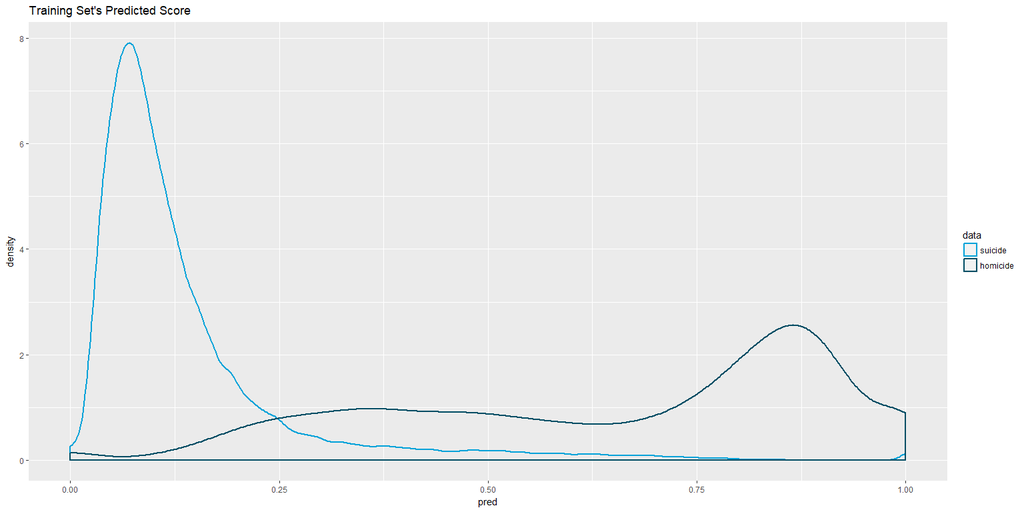

```r
train2$pred = predict(logmod,  newdata = train2, type = 'response')
ggplot( train2, aes( pred, color = as.factor(label))) +
  geom_density( size = 1 ) +
  ggtitle( "Training Set's Predicted Score" ) +
  scale_color_economist( name = "data", labels = c( "suicide", "homicide" ) )
```

با توجه به نمودارهای توزیع فوق، به نظر می رسد که جدایی بین دو کلاس تا حد خوبی انجام شده است. طبق دو نمودار فوق مقدار cutoff را به صورت تقریبی برابر 0.25 انتخاب می کنیم و نمودارهای confusion را به ازای آن رسم می کنیم.همچنین نمودار roc را برای این مدل رسم می کنیم. (توابع مربوط به این نمودارها در فایل unbalanced_functions آمده است)

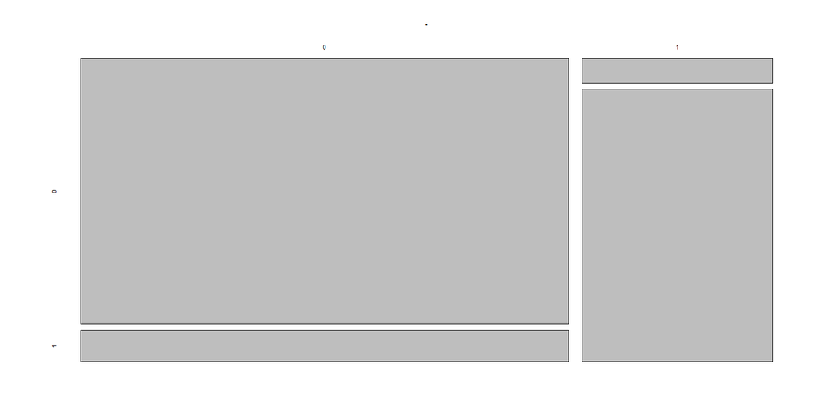

```r
table(train2$label,ifelse(fitted(logmod)>0.25,1,0)) %>% plot()
```

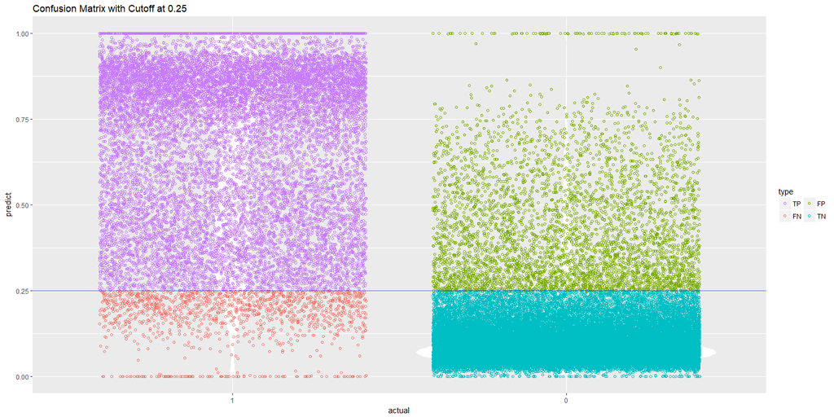

```r
cm_info = ConfusionMatrixInfo( data = train2, predict = "pred",
                               actual = "label", cutoff = .25 )
cm_info$plot
```

```r
TPR = sum(cm_info$data$type == "TP")/sum(train2$label ==1)
FPR = sum(cm_info$data$type == "FP")/sum(train2$label ==0)

TPR
```

```
## [1] 0.9170132
```

```r
FPR
```

```
## [1] 0.1065102
```

```r
cost_fp = 100;cost_fn = 100
roc_info = ROCInfo( data = cm_info$data, predict = "predict",
                    actual = "actual", cost.fp = cost_fp, cost.fn = cost_fn )
grid.draw(roc_info$plot)
```

[output not shown]

۵. ابتدا ۲۰ درصد داده را به صورت تصادفی به عنوان تست در نظر بگیرید. مدل را با استفاده از ۸۰ درصد باقی مانده برازش دهید. با استفاده از پارامتر قطع ۰.۵ نتایج را برای داده تست پیش بینی کنید. سپس کمیت های زیر را محاسبه کنید.

- P: positive samples
- N: negative samples
- TP: true positive TP (eqv. with hit)
- TN: true negative (eqv. with correct rejection)
- FP: false positive (eqv. with false alarm, Type I error)
- FN: false negative (eqv. with miss, Type II error)
- Accuracy (ACC) ACC = (TP+TN)/(P+T)
- False positive rate (FPR): 1- TN/N
- True positive rate (TPR): TP/P

مشابه آنچه در کلاس گفته شد نمایشی از چهار کمیت TN, TP,FP,FN به همراه داده ها رسم نمایید.

### پاسخ:

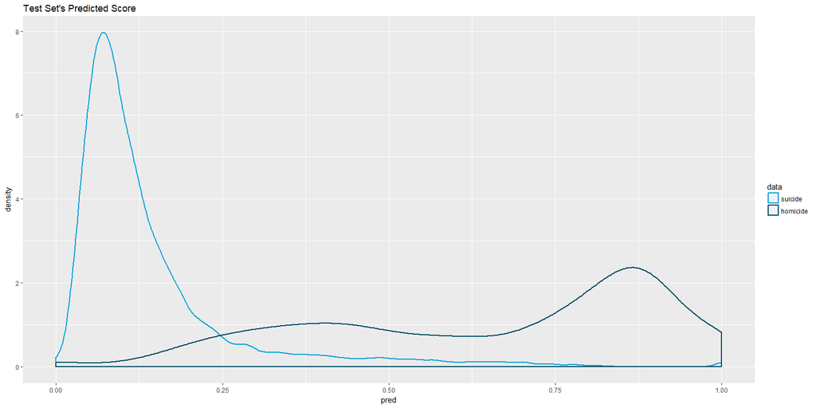

```r
n = nrow(train2)
train_indices = sample(1:n,size = 0.8*n, replace = F)
test_indices = c(1:n)[-train_indices]

train_data = train2[train_indices,]
test_data = train2[test_indices,]

logmod = glm(label~ResidentStatus+Age+PlaceOfDeathAndDecedentsStatus+
               PlaceOfInjury+CauseRecode358+RaceRecode3+Education+Sex+MaritalStatus+MethodOfDisposition,
             data = train_data,family = binomial(link = 'logit'))
test_data$pred = predict(logmod,  newdata = test_data, type = 'response')
train_data$pred = predict(logmod,  newdata = train_data, type = 'response')

ggplot( test_data, aes( pred, color = as.factor(label))) +
  geom_density( size = 1 ) +
  ggtitle( "Test Set's Predicted Score" ) +
  scale_color_economist( name = "data", labels = c( "suicide", "homicide" ) )
```

```r
cm_info = ConfusionMatrixInfo( data = test_data, predict = "pred",
                               actual = "label", cutoff = .5)
results = cm_info$data$type
P = sum(results == "FN" | results == "TP")
P
```

```
## [1] 3399
```

```r
N = sum(results == "FP" | results == "TN")
N
```

```
## [1] 8595
```

```r
TP = sum(results == "TP")
TP
```

```
## [1] 2307
```

```r
TN = sum(results == "TN")
TN
```

```
## [1] 8295
```

```r
FP = sum(results == "FP")
FP
```

```
## [1] 300
```

```r
FN = sum(results == "FN")
FN
```

```
## [1] 1092
```

```r
ACC = (TP+TN)/(P+N)
ACC
```

```
## [1] 0.883942
```

```r
TPR = TP/P
TPR
```

```
## [1] 0.678729
```

```r
FPR = FP/N
FPR
```

```
## [1] 0.03490401
```

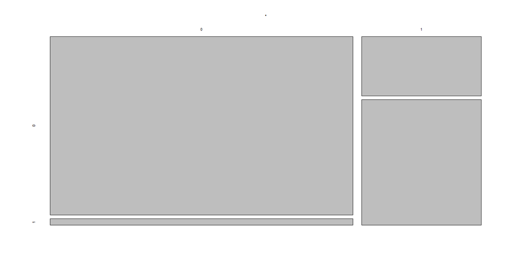

```r
table(test_data$label,ifelse(test_data$pred>0.5,1,0)) %>% plot()
```

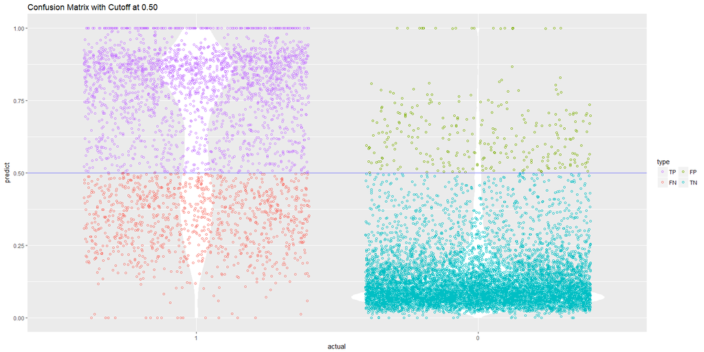

```r
cm_info$plot
```

۶. نمودار صحت مدل (accuracy) را بر حسب مقادیر مختلف قطع برای داده تست رسم نمایید. کدام پارامتر قطع بالاترین صحت را در پیش بینی داراست؟

### پاسخ:

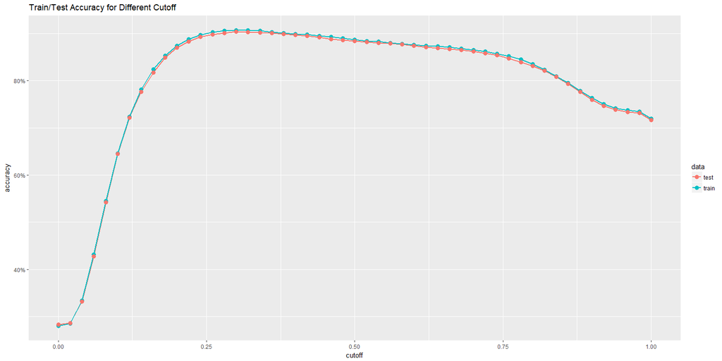

```r
accuracy_info = AccuracyCutoffInfo( train = train_data, test = test_data,
                                    predict = "pred", actual = "label" )
accuracy_info$plot
```

```r
accuracy_info$data$cutoff[which.max(accuracy_info$data$test)]
```

```
## [1] 0.3
```

۷. نمودار ROC را برای داده های قسمت قبل رسم نمایید. همچنین نقطه مربوط به بهترین پارامتر قطع را مشخص نمایید.

### پاسخ:

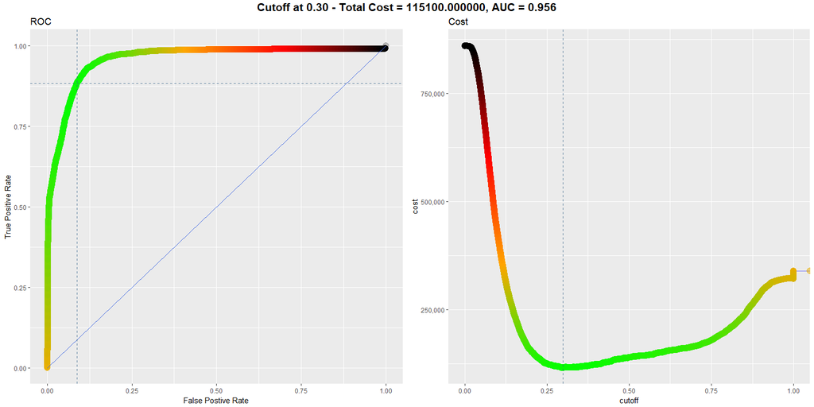

```r
cost_fp = 100;cost_fn = 100
roc_info = ROCInfo( data = cm_info$data, predict = "predict",
                    actual = "actual", cost.fp = cost_fp, cost.fn = cost_fn )
grid.draw(roc_info$plot)
```

```r
cutoff = roc_info$cutoff
cutoff
```

```
## [1] 0.2987683
```

حال با استفاده از cutoff به دست آمده دوباره پیش بینی را انجام داده و TPR و FPR را به دست می آوریم.

```r
cm_info = ConfusionMatrixInfo( data = test_data, predict = "pred",
                               actual = "label", cutoff = cutoff)
results = cm_info$data$type
P = sum(results == "FN" | results == "TP")
P
```

```
## [1] 3399
```

```r
N = sum(results == "FP" | results == "TN")
N
```

```
## [1] 8595
```

```r
TP = sum(results == "TP")
TP
```

```
## [1] 2999
```

```r
TN = sum(results == "TN")
TN
```

```
## [1] 7844
```

```r
FP = sum(results == "FP")
FP
```

```
## [1] 751
```

```r
FN = sum(results == "FN")
FN
```

```
## [1] 400
```

```r
ACC = (TP+TN)/(P+N)
ACC
```

```
## [1] 0.9040354
```

```r
TPR = TP/P
TPR
```

```
## [1] 0.8823183
```

```r
FPR = FP/N
FPR
```

```
## [1] 0.08737638
```

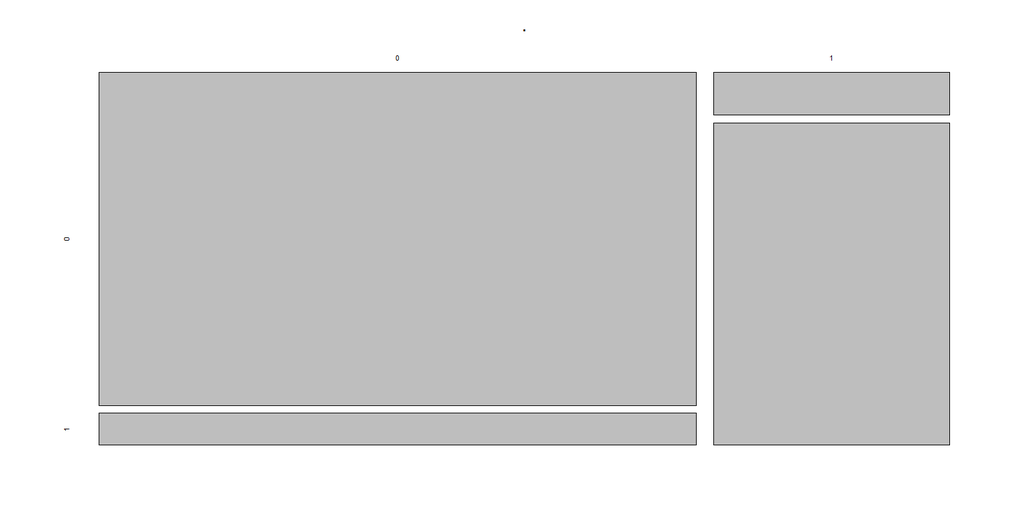

```r
table(test_data$label,ifelse(test_data$pred>cutoff,1,0)) %>% plot()
```

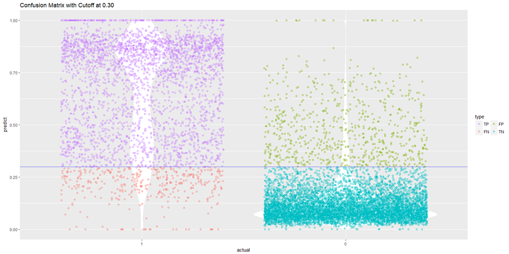

```r
cm_info$plot
```

***

۸. با قرار دادن کمیت nfolds = 5 و با استفاده از H20 مدل مساله را بسازید و نتیجه حاصل را ارزیابی کنید.

### پاسخ:

```r
library(h2o)
h2o.init(nthreads = -1, max_mem_size = '2g', ip = "127.0.0.1", port = 50001)
```

```
##  Connection successful!
##
## R is connected to the H2O cluster:
##     H2O cluster uptime:         13 hours 2 minutes
##     H2O cluster version:        3.16.0.2
##     H2O cluster version age:    4 months and 27 days !!!
##     H2O cluster name:           H2O_started_from_R_MKH_eol133
##     H2O cluster total nodes:    1
##     H2O cluster total memory:   1.60 GB
##     H2O cluster total cores:    4
##     H2O cluster allowed cores:  4
##     H2O cluster healthy:        TRUE
##     H2O Connection ip:          127.0.0.1
##     H2O Connection port:        50001
##     H2O Connection proxy:       NA
##     H2O Internal Security:      FALSE
##     H2O API Extensions:         Algos, AutoML, Core V3, Core V4
##     R Version:                  R version 3.4.3 (2017-11-30)
```

```r
htrain = as.h2o(train2)
chglm = h2o.glm(y = "label", x= colnames(train2)[1:12],
                training_frame = htrain, family="binomial",nfolds = 5)
chglm
```

```
## Model Details:
## ==============
##
## H2OBinomialModel: glm
## Model ID:  GLM_model_R_1524762843889_149
## GLM Model: summary
##     family  link                                regularization
## 1 binomial logit Elastic Net (alpha = 0.5, lambda = 4.466E-4 )
##   number_of_predictors_total number_of_active_predictors number_of_iterations
## 1                         12                          12                    5
##   training_frame
## 1         train2
##
## Coefficients: glm coefficients
##                             names coefficients standardized_coefficients
## 1                       Intercept   -79.775280                 -1.311560
## 2                  ResidentStatus     0.076068                  0.041357
## 3                    MonthOfDeath     0.001291                  0.004376
## 4                             Age    -0.015875                 -0.330090
## 5  PlaceOfDeathAndDecedentsStatus    -0.087372                 -0.171110
## 6                DayOfWeekOfDeath     0.003412                  0.006830
## 7                   PlaceOfInjury     0.095665                  1.439571
## 8                  CauseRecode358     0.183183                  3.007849
## 9                     RaceRecode3     0.990393                  0.761490
## 10                      Education    -0.183509                 -0.312137
## 11                            Sex    -0.318153                 -0.132096
## 12                  MaritalStatus     0.119417                  0.118621
## 13            MethodOfDisposition    -0.036410                 -0.064339
##
## H2OBinomialMetrics: glm
## ** Reported on training data. **
##
## MSE:  0.07933341
## RMSE:  0.2816619
## LogLoss:  0.3667124
## Mean Per-Class Error:  0.1012226
## AUC:  0.9549194
## Gini:  0.9098389
## R^2:  0.6071024
## Residual Deviance:  45948.37
```

[output cut: 71 more lines]

```
## ---
##                        mean          sd cv_1_valid cv_2_valid cv_3_valid
## precision         0.7986611 0.014813986  0.8312676 0.79390144  0.7946092
## r2                0.6037922 0.016815545  0.6335229  0.6019952  0.6016877
## recall              0.87849 0.007084314 0.88459235   0.870188  0.8784267
## residual_deviance  9233.258   209.19276   9581.644   9410.361   8941.629
## rmse              0.2827155 0.005930208 0.27146578  0.2826623 0.28405747
## specificity        0.913351 0.007478075  0.9305749  0.9129885  0.9107206
##                   cv_4_valid cv_5_valid
## precision          0.7666492  0.8068783
## r2                0.56257147  0.6191837
## recall            0.86560094 0.89364195
## residual_deviance   8822.656   9409.996
## rmse               0.2970154 0.27837655
## specificity        0.8974536  0.9150175
```

۹. آیا ما میتوانیم سرویسی به قضات ارایه کنیم تا با استفاده از اطلاعات مرگ بتوانند موارد مشکوک به قتل را از خودکشی تفکیک دهند؟

### پاسخ:

می توان سیستمی را بر مبنای این داده ها پیشنهاد داد، گرچه بدون خطا نخواهد بود. نکته ی مهم این است که در دادگاه ها اصولا تشخیص انسان بی گناه به عنوان گناهکار هزینه ی بیشتری نسبت به بی گناه تشخیص دادن انسان های گناهکار دارد. به عبارت دیگر باید در تعیین cutoff، هزینه ی FP را بیشتر از هزینه ی FN قرار دهیم.نتیج برای دو حالت مختلف هزینه ی FN و FP در زیر آمده است.

```r
cost_fp = 200;cost_fn = 100
roc_info = ROCInfo( data = cm_info$data, predict = "predict",
                    actual = "actual", cost.fp = cost_fp, cost.fn = cost_fn )

cutoff = roc_info$cutoff

cm_info = ConfusionMatrixInfo( data = test_data, predict = "pred",
                               actual = "label", cutoff = cutoff)
results = cm_info$data$type
P = sum(results == "FN" | results == "TP")
N = sum(results == "FP" | results == "TN")
TP = sum(results == "TP")
TN = sum(results == "TN")
FP = sum(results == "FP")
FN = sum(results == "FN")
ACC = (TP+TN)/(P+N)
ACC
```

```
## [1] 0.8786893
```

```r
TPR = TP/P
TPR
```

```
## [1] 0.6284201
```

```r
FPR = FP/N
FPR
```

```
## [1] 0.02233857
```

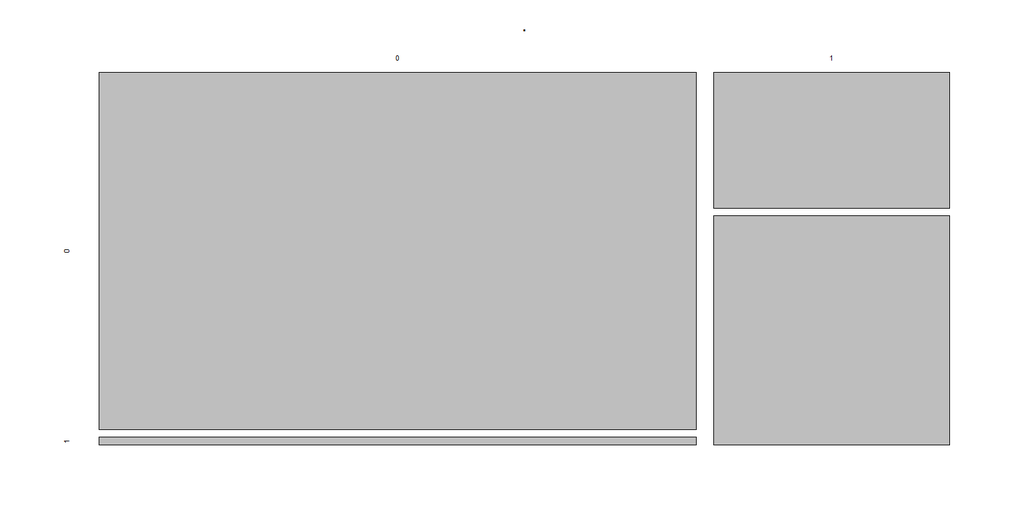

```r
table(test_data$label,ifelse(test_data$pred>cutoff,1,0)) %>% plot()
```

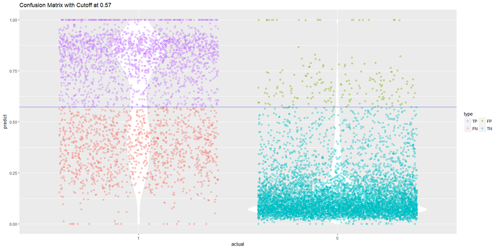

```r
cm_info$plot
```

```r
cost_fp = 300;cost_fn = 100
roc_info = ROCInfo( data = cm_info$data, predict = "predict",
                    actual = "actual", cost.fp = cost_fp, cost.fn = cost_fn )

cutoff = roc_info$cutoff

cm_info = ConfusionMatrixInfo( data = test_data, predict = "pred",
                               actual = "label", cutoff = cutoff)
results = cm_info$data$type
P = sum(results == "FN" | results == "TP")
N = sum(results == "FP" | results == "TN")
TP = sum(results == "TP")
TN = sum(results == "TN")
FP = sum(results == "FP")
FN = sum(results == "FN")
ACC = (TP+TN)/(P+N)
ACC
```

```
## [1] 0.861264
```

```r
TPR = TP/P
TPR
```

```
## [1] 0.5289791
```

```r
FPR = FP/N
FPR
```

```
## [1] 0.007329843
```

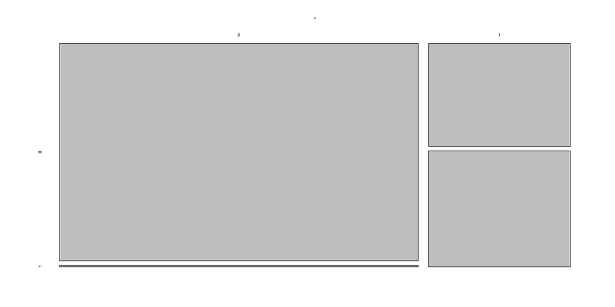

```r
table(test_data$label,ifelse(test_data$pred>cutoff,1,0)) %>% plot()
```

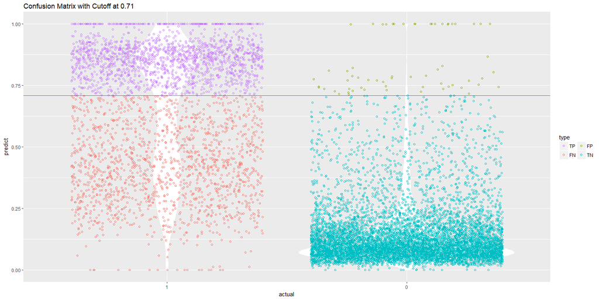

```r
cm_info$plot
```

البته نکته ای اینجا قابل تامل است که داده های آموزشی که ما داشتیم نتایج دادگاه ها و جکم قاضی ها بودند که ممکن است همراه با خطا باشد. این که سیستمی را بر این اساس آموزش هیم و از آن استفاده کنیم، بنابراین از دو جهت خطا خواهد داشت که شاید مناسب نباشد.